# From dose response data to the IC50

15 August 2019

## Prerequisities

1. Please make sure you've got Prism and Excel installed
2. Download and unzip the course material. If you haven't received the email with the ZIP archive, **or you'd like to get the most recent version of the notes**, you can
   - clone the GitHub repository in your MacOS terminal

     ```
     git clone https://github.com/mevers/DRC_workshop
     ```

   - download the ZIP archive from the GitHub repository in your MacOS terminal

     ```
     curl -O https://github.com/mevers/DRC_workshop/raw/master/DRC_workshop.zip
     unzip DRC_workshop.zip
     ```

   - go to [`https://github.com/mevers/DRC_workshop/blob/master/DRC_workshop.zip`](https://github.com/mevers/DRC_workshop/blob/master/DRC_workshop.zip) in your browser and click on the `Download` button
3. Open file `DRC_workshop_notes.html` in your browser

## Dose-response model

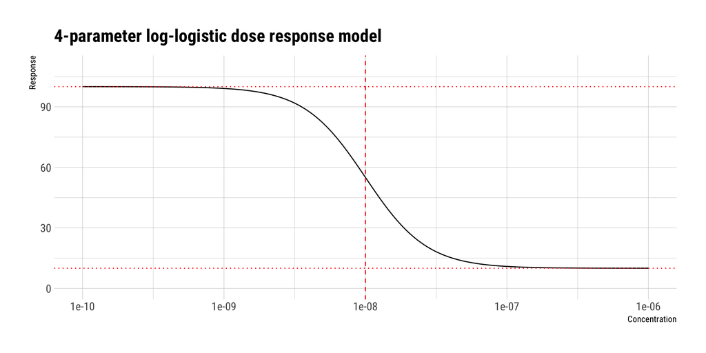

\[ LL4(C, b, c, d, e) = c + \frac{d-c}{1 + \exp{\left(b\log{\frac{C}{e}}\right)}} \]

## Challenge 1: No-replicate dose-response data

### Two teams

1. Two teams  
   Team 1: Open `DRC_workshop_ITS_rep1_data` in Excel  
   Team 2: Open `DRC_workshop_ITS_rep1_data_vehicle_normalised` in Excel
2. Based on the data in your Excel sheet, perform a dose-response analysis in Prism
3. Inspect the results and parameter estimates from the model fit
4. **What's the difference between the IC50 determined from the vehicle-normalised data vs. the IC50 determined from the un-normalised data?**

### What does that mean?

## Challenge 2: Replicate dose-response data

### Two teams

1. Two teams  
   Team 1: Open `DRC_workshop_full_data` in Excel  
   Team 2: Open `DRC_workshop_full_data_vehicle_normalised` in Excel
2. Based on the data in your Excel sheet, perform a dose-response analysis in Prism
3. Inspect the results and parameter estimates from the model fit
4. **What's the difference between the IC50 determined from the vehicle-normalised data vs. the IC50 determined from the un-normalised data?**